# Exercício 2

Henrique Capatto

# Geração de números aleatórios

Execução do segundo exercício proposto

## Método da Inversão

O exercício em questão porpõe gerar números aleatórios que sigam a função de probabilidade:

$$\mathbb{P}(X=k) = \frac{(e^{-\lambda} \lambda ^k )} {k!}, \forall k\in (0,1,2,...)$$

1. Determinar a função acumulada de $x$;
   $$F_x(u)^{-1}=x_i$$
2. E Definir $u$, tal que:
   $$F_x(x_{i-1})< u \leq F_x(x)$$
3. Gerar amostras aleatórias de acordo com uma distribuição uniforme(0,1);
4. Aplicar a função inversa nos números recém-gerados;

$$f(x+1)=\frac{\lambda f(X)} {x+1}; F(x+1)=F(x)+f(x+1)$$

```r
numale = function(lambda){

  exp01=exp(-lambda)

  i=1

  contr=0

  unif01 <- NULL

  while(contr!=i){

    unif01[i]=runif(1)

    if(prod(unif01) < exp01){

      contr=i

    }else{
      i=i+1
    }
  }

return(i-1)
}

rpois2 = function(n,lambda){

Y=replicate(n,numale(lambda))

return (Y)

}

n <- 1e4

lambda <- 10

amostra=rpois2(n,lambda)

maxx=max(amostra)
```

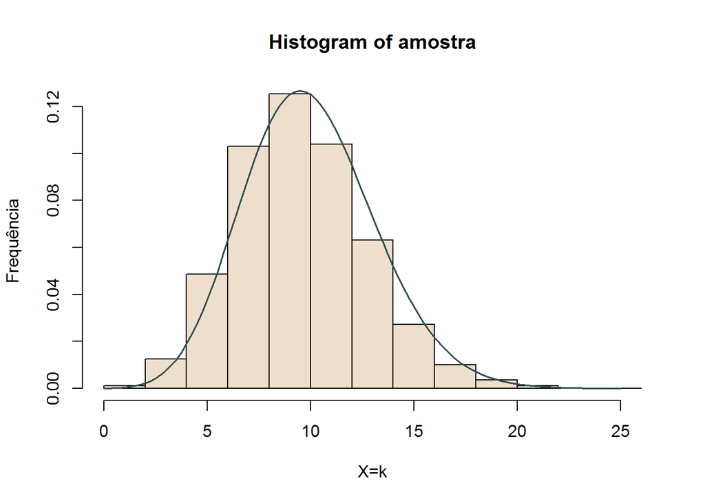

```r
#pprob <- dpois(indexp,lambda)

#plot(indexp,pprob*n,type='l',lwd=1.5,col="blue")

hist(amostra,col="antiquewhite2",border="black",xlab="X=k",
ylab="Frequência",freq=FALSE)

curve(((exp(-lambda)*lambda^x)/factorial(x)),xlim=c(0,maxx),
lw=1.5,col="darkslategray",type='l',add=TRUE)
```

O teste se utilizará para validar a hipótese será o Chi-Quadrado de Aderência, possuinte do objetivo de testar a adeuqabilidade de um modelo probabilistico em relação a um conjunto de dados observados. Faremos o teste utilizando os quartis téoricos e os orginários da amostra aleatória. A hipótese nula é a de que a amostra segue a distribuição deseja. A alternativa, é a de que não segue.

Definição de $\alpha=$ 0.05

OS quartis teóricos desta distribuição são determinados pela pontos em que a função acumulada atinge os valores pré-especificada dos quantis(0.25,0.5,0.75).

```r
quartis = c(0,q1,q2,q3,3*lambda)

resTmp = cut(amostra, quartis, include.lowest=TRUE)

obs = as.integer(table(resTmp))

propor=prop.table(table(resTmp))

proporesp = c(p1,p2,p3,p4)

p_valor=chisq.test(cbind(propor, proporesp))[3]
prop.table(table(resTmp))
```

[output not shown]

O p-valor resultante é: 0.9680347

Logo, se p-valor for $<0.05$, rejeitar-se-á a hipótese nula. Caso contrário, não se preterirá.